# NLP Cleaning and Exploring Data

Rishikesh Pillay

8/20/2021

# Overview

In this Markdown File I am going to Load data try to understand data. Do some cleaning and Exploratory analysis on data.

Source :- ‘https://d396qusza40orc.cloudfront.net/dsscapstone/dataset/Coursera-SwiftKey.zip’

In below code I am downloading data if it is already not present and after unziping files in local system I am deleting zip file which I don’t need anymore.

# Downloading Data

```r
#Downloading Data

fileURL <- "https://d396qusza40orc.cloudfront.net/dsscapstone/dataset/Coursera-SwiftKey.zip"

if(!dir.exists('../Coursera-SwiftKey/final/en_US/')){
        dir.create('../Data')
        download.file(fileURL, destfile = "../Coursera-SwiftKey.zip")
        unzip("../Coursera-SwiftKey.zip", exdir = "../Coursera-SwiftKey")
        file.remove('../Coursera-SwiftKey.zip')

}
```

Now I will load data using readlines .I am Loading just English language Data. That includes blog,news and twitter data files from US-English text files.

# Loading Data

```r
#Loading Data

# Twitter Reading
twitter_con <- file("../Coursera-SwiftKey/final/en_US/en_US.twitter.txt", 'r')
twitter_lines <- readLines(twitter_con)
close(twitter_con)

# News
news_con <- file("../Coursera-SwiftKey/final/en_US/en_US.news.txt", "r")
news_lines <- readLines(news_con)
close(news_con)

# Blogs
blog_con <- file("../Coursera-SwiftKey/final/en_US/en_US.blogs.txt", 'r')
blog_lines <- readLines(blog_con)
close(blog_con)
```

# Summarizing Data

Using Head function on all sources for understanding data.

```
[1] "Twitter"
```

```
[1] "How are you? Btw thanks for the RT. You gonna be in DC anytime soon? Love to see you. Been way, way too long."
[2] "When you meet someone special... you'll know. Your heart will beat more rapidly and you'll smile for no reason."
```

```
[1] "News"
```

```
[1] "He wasn't home alone, apparently."
[2] "The St. Louis plant had to close. It would die of old age. Workers had been making cars there since the onset of mass automotive production in the 1920s."
```

```
[1] "Blog"
```

```
[1] "In the years thereafter, most of the Oil fields and platforms were named after pagan â\200œgodsâ\200\235."
[2] "We love you Mr. Brown."
```

```r
library(stringi)

summary <- data.frame(Source = c("Twitter", 'News', 'Blog'),
                      File_size_mb= c(file.size('../Coursera-SwiftKey/final/en_US/en_US.twitter.txt')/1024^2, file.size('../Coursera-SwiftKey/final/en_US/en_US.news.txt')/1024^2, file.size('../Coursera-SwiftKey/final/en_US/en_US.blogs.txt')/1024^2),
                      Number_of_entries = c(length(twitter_lines), length(news_lines), length(blog_lines)),
                      Word_count = c(sum(stri_count_words(twitter_lines)), sum(stri_count_words(news_lines)), sum(stri_count_words(blog_lines))))

print(summary)
```

```
   Source File_size_mb Number_of_entries Word_count
1 Twitter     159.3641           2360148   30218125
2    News     196.2775             77259    2693898
3    Blog     200.4242            899288   38154238
```

# Cleaning and Sampling

This dataset is fairly large. I don’t necessarily need to load the entire dataset in to build my algorithms.

## Basic Cleaning and Sampling

Here I will Sample just 2% of data of all sources(twitter, blog and news). Also I tried to delete Raw files as there were very large ,we did sampling just to get rid of them and to free up RAM.

```r
# Sampling using random binomial generation with just 2% probability

set.seed(222)
t <- rbinom(length(twitter_lines), 1, prob = .02)
b <- rbinom(length(blog_lines), 1, prob = .02)
n <- rbinom(length(news_lines), 1, prob = .02)

#subsetting
twitter <- subset(twitter_lines, as.logical(t))
blog <- subset(blog_lines, as.logical(b))
news <- subset(news_lines, as.logical(n))

# Cleaning work space or Ram
rm(list=setdiff(ls(), c("twitter","blog", 'news')))
```

## Cleaning with tm package

After the sampling is created, I shall create a corpus and perform cleansing into the corpus. In cleansing process, we will make use of the tm package commands to remove any punctuation, covert all text into lower case, remove any numbering, remove any white-spaces, and remove hyperlinks (https) characters.

```r
# load tm package
library(tm)
library(quanteda)

mycorpus <- VCorpus(VectorSource(c(twitter, news, blog)))
#The result is a structure of type VCorpus (‘virtual corpus’ that is, loaded into memory)
print(mycorpus)
```

```
<<VCorpus>>
Metadata:  corpus specific: 0, document level (indexed): 0
Content:  documents: 66875
```

```r
# perform data cleasing into "myCorpus"" variable
toSpace <- content_transformer(function(x, pattern) gsub(pattern," ", x))

# Removing hyperlink
mycorpus <- tm_map(mycorpus, toSpace, "(f|ht)tp(s?)://(.*)[.][a-z]+")

# Removing tag
mycorpus <- tm_map(mycorpus, toSpace, "@[^\\s]+")
# Making lowercase
mycorpus <- tm_map(mycorpus, content_transformer(tolower))
# Removing stopwords
updatedStopwords <- c(stopwords('en'), "can", "will", "want", "just", "like")
mycorpus <- tm_map(mycorpus, removeWords, updatedStopwords)
# Removing punctuation
mycorpus <- tm_map(mycorpus, removePunctuation)
# Removing digit
mycorpus <- tm_map(mycorpus, removeNumbers)
# Removing whitespace
mycorpus <- tm_map(mycorpus, stripWhitespace)

print(mycorpus)
```

```
<<VCorpus>>
Metadata:  corpus specific: 0, document level (indexed): 0
Content:  documents: 66875
```

# Exploratory Analysis

To analyze the textual data, we use a Document-Term Matrix (DTM) representation: documents as the rows, terms/words as the columns, frequency of the term in the document as the entries. Because the number of unique words in the corpus the dimension can be large.

```r
library(RWeka)

options(mc.cores=1)

getFreq <- function(tdm) {
  freq <- sort(rowSums(as.matrix(tdm)), decreasing = TRUE)
  return(data.frame(word = names(freq), freq = freq))
}
bigram <- function(x) NGramTokenizer(x, Weka_control(min = 2, max = 2))
trigram <- function(x) NGramTokenizer(x, Weka_control(min = 3, max = 3))
```

Unigram ,Bigram and Trigram data

```r
library(tm)

# Create the dtm from the corpus:
corpus_dtm <- TermDocumentMatrix(mycorpus)
freq1 <- getFreq(removeSparseTerms(corpus_dtm, 0.9999))

# Create the dtm from the corpus:
corpus_dtm_bigram <- TermDocumentMatrix(mycorpus, control = list(tokenize = bigram))
# Print out corpus_dtm_bigram data
freq2 <- getFreq(removeSparseTerms(corpus_dtm_bigram, 0.9999))


# Create the dtm from the corpus:
corpus_dtm_trigram <- TermDocumentMatrix(mycorpus, control = list(tokenize = trigram))
freq3 <- getFreq(removeSparseTerms(corpus_dtm_trigram, 0.9999))
```

Also we used remove sparse term with sparsity treshold of 0.9999. Sparsity refers to the threshold of relative document frequency for a term, above which the term will be removed, then with our treshold, it will remove only terms that are more sparse than 0.9999.

## Word cloud

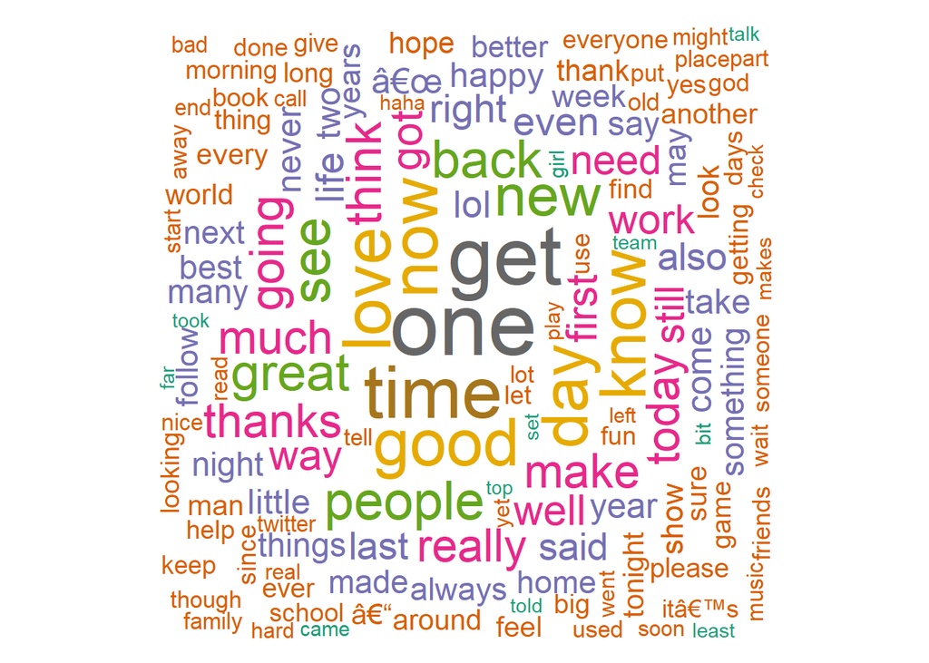

```r
library(RColorBrewer)
library(wordcloud)

# Wordcloud Just For Unigram
set.seed(1234)
wordcloud(words = freq1$word, freq = freq1$freq, min.freq = 1,
max.words=200, random.order=FALSE, rot.per=0.35,
colors=brewer.pal(8, "Dark2"))
```

Word Clouds for Bigram or trigram are not that useful as much as bar plots.

Now I will plot barplot (top 10) of unigrams,bigrams and trigrams as. It is easy to understand barplots .

## Barplot

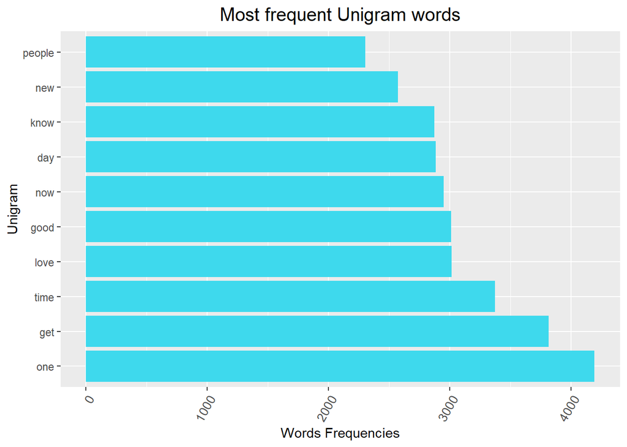

```r
library(ggplot2)

ggplot(freq1[1:10, ], aes(reorder(word,-freq), freq)) +
        labs(x = 'Unigram', y = "Words Frequencies") +
        theme(axis.text.x = element_text(
                angle = 60,
                size = 10,
                hjust = 1
        )) +
        geom_bar(stat = "identity", fill = I("#3ED9ED")) +
        coord_flip() +  ggtitle("Most frequent Unigram words") +
        theme(plot.title = element_text(hjust = 0.5)) +
        theme(plot.title = element_text(size = 15))
```

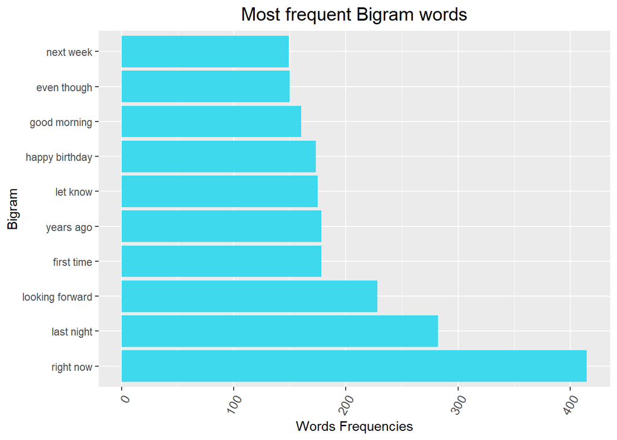

```r
#Bigram
ggplot(freq2[1:10, ], aes(reorder(word,-freq), freq)) +
        labs(x = 'Bigram', y = "Words Frequencies") +
        theme(axis.text.x = element_text(
                angle = 60,
                size = 10,
                hjust = 1
        )) +
        geom_bar(stat = "identity", fill = I("#3ED9ED")) +
        coord_flip() +  ggtitle("Most frequent Bigram words") +
        theme(plot.title = element_text(hjust = 0.5)) +
        theme(plot.title = element_text(size = 15))
```

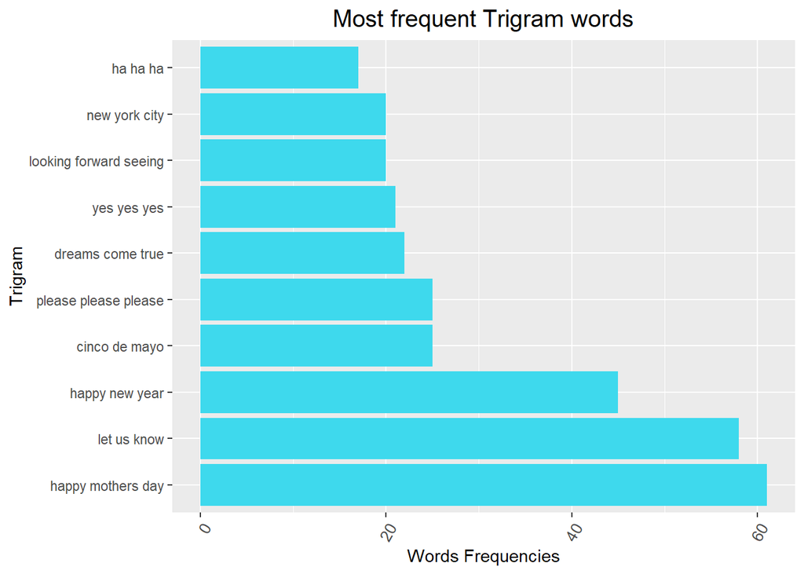

```r
# Trigram
ggplot(freq3[1:10, ], aes(reorder(word,-freq), freq)) +
        labs(x = 'Trigram', y = "Words Frequencies") +
        theme(axis.text.x = element_text(
                angle = 60,
                size = 10,
                hjust = 1
        )) +
        geom_bar(stat = "identity", fill = I("#3ED9ED")) +
        coord_flip() +  ggtitle("Most frequent Trigram words") +
        theme(plot.title = element_text(hjust = 0.5)) +
        theme(plot.title = element_text(size = 15))
```

# Model Ideas

I have done examining the dataset and get some interesting findings from the exploratory analysis. Now I are ready to train and create our first predictive model. Machine Learning is an iterative process where we preprocess the training data, then train and evaluate the model and repeat the steps again iteratively to get better performance model based on our evaluation metrics. In shiny app I try to implement prediction of words based on previous words typed by user.